# Classification_Models

## **Building Classification Models Using Wines Data**

### **1. Loading the dataset**

```python
import pandas as pd
              import numpy as np
              import seaborn as sns
              import matplotlib.pyplot as plt
              from sklearn import datasets
```

```python
# Loading the dataset
              wines = datasets.load_wine()
              df = pd.concat([pd.DataFrame(wines.data, columns=wines.feature_names), pd.DataFrame(wines.target, columns=['class'])], axis=1)
              df['class'] = df['class'].map({0: 'class_0', 1: 'class_1', 2: 'class_2'})
```

### **2. Data Exploration**

```python
# Top 5 records of the wines data
            df.head()
```

|  | alcohol | malic_acid | ash | alcalinity_of_ash | magnesium | total_phenols | flavanoids | nonflavanoid_phenols | proanthocyanins | color_intensity | hue | od280/od315_of_diluted_wines | proline | class |
| --- | --- | --- | --- | --- | --- | --- | --- | --- | --- | --- | --- | --- | --- | --- |
| 0 | 14.23 | 1.71 | 2.43 | 15.6 | 127.0 | 2.80 | 3.06 | 0.28 | 2.29 | 5.64 | 1.04 | 3.92 | 1065.0 | class_0 |
| 1 | 13.20 | 1.78 | 2.14 | 11.2 | 100.0 | 2.65 | 2.76 | 0.26 | 1.28 | 4.38 | 1.05 | 3.40 | 1050.0 | class_0 |
| 2 | 13.16 | 2.36 | 2.67 | 18.6 | 101.0 | 2.80 | 3.24 | 0.30 | 2.81 | 5.68 | 1.03 | 3.17 | 1185.0 | class_0 |
| 3 | 14.37 | 1.95 | 2.50 | 16.8 | 113.0 | 3.85 | 3.49 | 0.24 | 2.18 | 7.80 | 0.86 | 3.45 | 1480.0 | class_0 |
| 4 | 13.24 | 2.59 | 2.87 | 21.0 | 118.0 | 2.80 | 2.69 | 0.39 | 1.82 | 4.32 | 1.04 | 2.93 | 735.0 | class_0 |

```python
# Bottom 5 records of the wines data
            df.tail()
```

|  | alcohol | malic_acid | ash | alcalinity_of_ash | magnesium | total_phenols | flavanoids | nonflavanoid_phenols | proanthocyanins | color_intensity | hue | od280/od315_of_diluted_wines | proline | class |
| --- | --- | --- | --- | --- | --- | --- | --- | --- | --- | --- | --- | --- | --- | --- |
| 173 | 13.71 | 5.65 | 2.45 | 20.5 | 95.0 | 1.68 | 0.61 | 0.52 | 1.06 | 7.7 | 0.64 | 1.74 | 740.0 | class_2 |
| 174 | 13.40 | 3.91 | 2.48 | 23.0 | 102.0 | 1.80 | 0.75 | 0.43 | 1.41 | 7.3 | 0.70 | 1.56 | 750.0 | class_2 |
| 175 | 13.27 | 4.28 | 2.26 | 20.0 | 120.0 | 1.59 | 0.69 | 0.43 | 1.35 | 10.2 | 0.59 | 1.56 | 835.0 | class_2 |
| 176 | 13.17 | 2.59 | 2.37 | 20.0 | 120.0 | 1.65 | 0.68 | 0.53 | 1.46 | 9.3 | 0.60 | 1.62 | 840.0 | class_2 |
| 177 | 14.13 | 4.10 | 2.74 | 24.5 | 96.0 | 2.05 | 0.76 | 0.56 | 1.35 | 9.2 | 0.61 | 1.60 | 560.0 | class_2 |

```python
# Technical information of the data
            df.info()
```

```
<class 'pandas.core.frame.DataFrame'>
            RangeIndex: 178 entries, 0 to 177
            Data columns (total 14 columns):
            #   Column                        Non-Null Count  Dtype
            ---  ------                        --------------  -----
            0   alcohol                       178 non-null    float64
            1   malic_acid                    178 non-null    float64
            2   ash                           178 non-null    float64
            3   alcalinity_of_ash             178 non-null    float64
            4   magnesium                     178 non-null    float64
            5   total_phenols                 178 non-null    float64
            6   flavanoids                    178 non-null    float64
            7   nonflavanoid_phenols          178 non-null    float64
            8   proanthocyanins               178 non-null    float64
            9   color_intensity               178 non-null    float64
            10  hue                           178 non-null    float64
            11  od280/od315_of_diluted_wines  178 non-null    float64
            12  proline                       178 non-null    float64
            13  class                         178 non-null    object
            dtypes: float64(13), object(1)
            memory usage: 19.6+ KB
```

```python
# The dimension of the data
            print(f'The wines data has {df.shape[0]} rows and {df.shape[1]} columns:\n({df.columns.to_list()})')
```

```
The wines data has 178 rows and 14 columns:
            (['alcohol', 'malic_acid', 'ash', 'alcalinity_of_ash', 'magnesium', 'total_phenols', 'flavanoids', 'nonflavanoid_phenols', 'proanthocyanins', 'color_intensity', 'hue', 'od280/od315_of_diluted_wines', 'proline', 'class'])
```

**Descriptive Statistics**

Numeric Data

```python
df.select_dtypes(include=np.number).describe().round(2)
```

|  | alcohol | malic_acid | ash | alcalinity_of_ash | magnesium | total_phenols | flavanoids | nonflavanoid_phenols | proanthocyanins | color_intensity | hue | od280/od315_of_diluted_wines | proline |
| --- | --- | --- | --- | --- | --- | --- | --- | --- | --- | --- | --- | --- | --- |
| count | 178.00 | 178.00 | 178.00 | 178.00 | 178.00 | 178.00 | 178.00 | 178.00 | 178.00 | 178.00 | 178.00 | 178.00 | 178.00 |
| mean | 13.00 | 2.34 | 2.37 | 19.49 | 99.74 | 2.30 | 2.03 | 0.36 | 1.59 | 5.06 | 0.96 | 2.61 | 746.89 |
| std | 0.81 | 1.12 | 0.27 | 3.34 | 14.28 | 0.63 | 1.00 | 0.12 | 0.57 | 2.32 | 0.23 | 0.71 | 314.91 |
| min | 11.03 | 0.74 | 1.36 | 10.60 | 70.00 | 0.98 | 0.34 | 0.13 | 0.41 | 1.28 | 0.48 | 1.27 | 278.00 |
| 25% | 12.36 | 1.60 | 2.21 | 17.20 | 88.00 | 1.74 | 1.20 | 0.27 | 1.25 | 3.22 | 0.78 | 1.94 | 500.50 |
| 50% | 13.05 | 1.87 | 2.36 | 19.50 | 98.00 | 2.36 | 2.13 | 0.34 | 1.56 | 4.69 | 0.96 | 2.78 | 673.50 |
| 75% | 13.68 | 3.08 | 2.56 | 21.50 | 107.00 | 2.80 | 2.88 | 0.44 | 1.95 | 6.20 | 1.12 | 3.17 | 985.00 |
| max | 14.83 | 5.80 | 3.23 | 30.00 | 162.00 | 3.88 | 5.08 | 0.66 | 3.58 | 13.00 | 1.71 | 4.00 | 1680.00 |

Categorical data

```python
df.select_dtypes(include=['object','category']).describe()
```

|  | class |
| --- | --- |
| count | 178 |
| unique | 3 |
| top | class_1 |
| freq | 71 |

**Exploring the relationship between numeric variables**

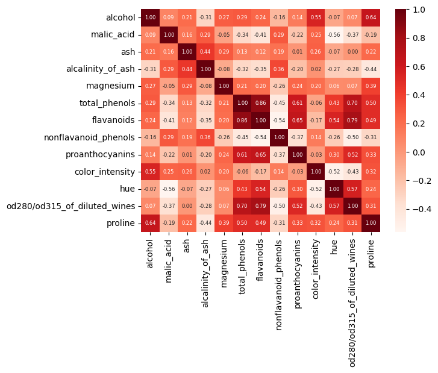

```python
sns.heatmap(df.select_dtypes(include=np.number).corr(), cmap='Reds', annot=True, annot_kws={'size':6}, fmt='.2f')
```

From the heatmap above, there is a strong positve relationship between `od280/od315_of_diluted_wines` and `total_phenols` and `flavanoids`.

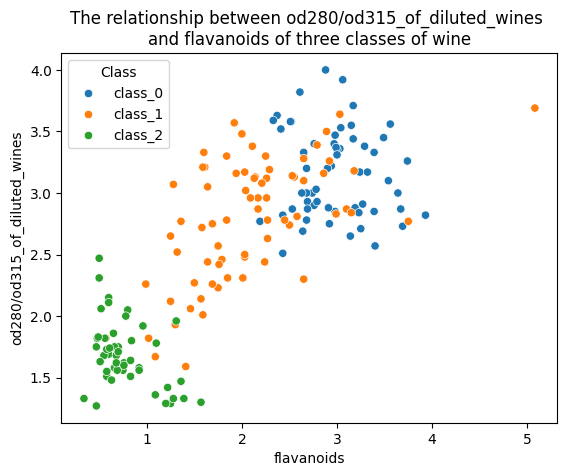

```python
sns.scatterplot(data=df, x = 'flavanoids', y = 'od280/od315_of_diluted_wines', hue='class')
            plt.title("The relationship between od280/od315_of_diluted_wines \nand flavanoids of three classes of wine")
            plt.legend(title = "Class")
            plt.show()
```

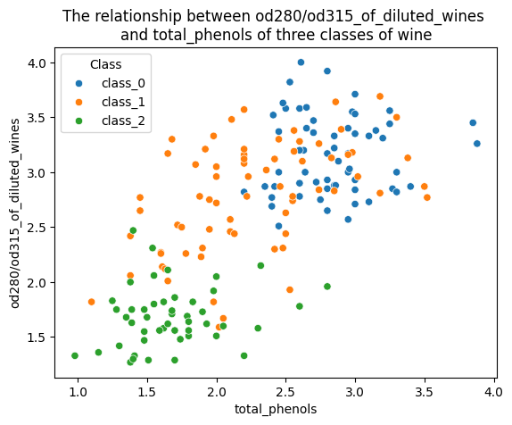

```python
sns.scatterplot(data=df, x = 'total_phenols', y = 'od280/od315_of_diluted_wines', hue='class')
            plt.title("The relationship between od280/od315_of_diluted_wines \nand total_phenols of three classes of wine")
            plt.legend(title = "Class")
            plt.show()
```

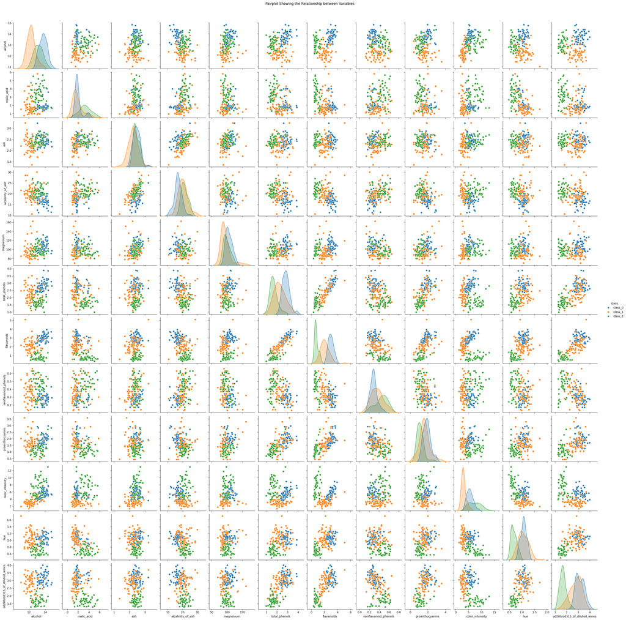

```python
sns.pairplot(data=df[df.columns.to_list()[:12] + ['class']], hue='class')#, height=1, aspect=1.25)
            plt.suptitle("Pairplot Showing the Relationship between Variables", y=1.02)
            plt.show()
```

### **3. Data Preparation**

##### **Checking and Handling Missing Values**

**Checking for the missing values**

```python
df.isna().sum()[df.isna().sum()!=0]
```

|  | 0 |
| --- | --- |

**dtype:** int64

There are no missing values in the dataset.

**Checking if there are duplicates in the dataset**

```python
df.duplicated().sum()
```

```
np.int64(0)
```

There are no duplicates in the dataset.

##### **Creating Train and Test Set**

```python
# Importing the required libraries
            from sklearn.model_selection import  train_test_split
            from sklearn.preprocessing import StandardScaler
            X_data = df.drop(columns=['class'])
            y_data = wines.target

            x_train, x_test, y_train, y_test = train_test_split(X_data, y_data, test_size=0.2, random_state=9072025) # Used 80%

            # Indentify numeric columns
            numeric_columns = df.select_dtypes(include=np.number).columns.to_list()
            # Scaling data (numeric features)
            # Define and initialize the scaler
            scaler = StandardScaler().fit(X_data)
            # Transform the data
            x_train[numeric_columns] = scaler.transform(x_train[numeric_columns])
            x_test[numeric_columns] = scaler.transform(x_test[numeric_columns])

            x_train.head()
```

|  | alcohol | malic_acid | ash | alcalinity_of_ash | magnesium | total_phenols | flavanoids | nonflavanoid_phenols | proanthocyanins | color_intensity | hue | od280/od315_of_diluted_wines | proline |
| --- | --- | --- | --- | --- | --- | --- | --- | --- | --- | --- | --- | --- | --- |
| 118 | -0.284874 | 0.981731 | -1.412851 | -1.049479 | -1.386122 | -1.065731 | -0.782361 | 0.549108 | -1.333159 | -0.717240 | -1.129518 | -0.694478 | -1.193845 |
| 44 | 0.061000 | -0.508390 | -0.974210 | -0.749194 | 0.509638 | 1.129464 | 0.974581 | -0.659563 | 0.769342 | -0.007825 | -0.339797 | 1.042827 | 0.439800 |
| 71 | 1.061565 | -0.741782 | 1.109334 | 1.653086 | -0.964842 | 1.049347 | 0.834026 | -1.223610 | 0.489009 | -0.725891 | 1.766126 | 0.774463 | -1.072834 |
| 83 | 0.061000 | 1.367726 | -0.170035 | 0.902373 | -1.035055 | -1.033684 | -0.441012 | 1.999513 | 0.050988 | -0.111642 | -0.515290 | -0.849846 | -0.738463 |
| 99 | -0.877801 | 0.748338 | -0.572122 | -0.448909 | -0.824415 | 0.889114 | 0.964541 | 0.710264 | 2.135968 | -1.193067 | 2.029366 | 0.308357 | -1.085572 |

```python
# Previewing the train target
            y_train[:5]
```

```
array([1, 0, 1, 1, 1])
```

### **4. Model Building**

**Loading the Required Libraries**

```python
from sklearn.metrics import accuracy_score, precision_score, recall_score, f1_score, confusion_matrix, ConfusionMatrixDisplay
```

#### **1. Logistic Regression**

**Training Logistic Model**

```python
# Import libraries
            from sklearn.linear_model import  LogisticRegression
            # Define the Model
            lr_model = LogisticRegression(random_state=10072025)
            # Train the Model
            lr_model.fit(x_train, y_train)
            # Make Predictions
            lr_predictions = lr_model.predict(x_test)
```

**Evaluating Logistic Regression Model**

```python
# Evaluate thr model
            print(f"Logistic Regression Model Metrics\n{'*'*40}\nAccuracy Score: {round(accuracy_score(y_test, lr_predictions), 4)}")
            print(f"Precision Score: {round(precision_score(y_test, lr_predictions, average='weighted'),4)}")
            print(f"Recall Score: {round(recall_score(y_test, lr_predictions, average='weighted'),4)}")
            print(f"F1 Score: {round(f1_score(y_test, lr_predictions, average='weighted'),4)}")
```

```
Logistic Regression Model Metrics
            Accuracy Score: 0.9722
            Precision Score: 0.9744
            Recall Score: 0.9722
            F1 Score: 0.9717
```

**Confusion Matrix**

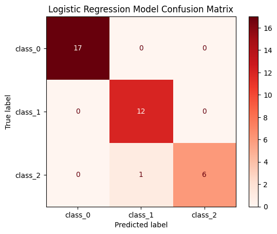

```python
lr_cm = confusion_matrix(y_test, lr_predictions)
            lr_disp = ConfusionMatrixDisplay(confusion_matrix=lr_cm, display_labels= wines.target_names)
            lr_disp.plot(cmap = 'Reds')
            plt.title('Logistic Regression Model Confusion Matrix')
            plt.show()
```

#### **2. Decision Tree Model**

**Training Decision Tree Classifier**

```python
# Import libraries
            from sklearn.tree import DecisionTreeClassifier
            # Define the Model
            dt_model = DecisionTreeClassifier(random_state=10072025)
            # Train the Model
            dt_model.fit(x_train, y_train)
            # Make Predictions
            dt_predictions = dt_model.predict(x_test)
```

**Evaluating Decision Tree Classifier**

```python
# Evaluate thr model
            print(f"Decision Tree Classifier Metrics\n{'*'*40}\nAccuracy Score: {round(accuracy_score(y_test, dt_predictions),4)}")
            print(f"Precision Score: {round(precision_score(y_test, dt_predictions, average='weighted'),4)}")
            print(f"Recall Score: {round(recall_score(y_test, dt_predictions, average='weighted'),4)}")
            print(f"F1 Score: {round(f1_score(y_test, dt_predictions, average='weighted'),4)}")
```

```
Decision Tree Classifier Metrics
            Accuracy Score: 0.8611
            Precision Score: 0.8675
            Recall Score: 0.8611
            F1 Score: 0.8628
```

**Confusion Matrix**

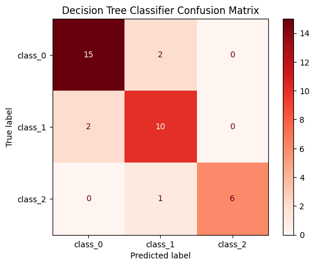

```python
dt_cm = confusion_matrix(y_test, dt_predictions)
            dt_disp = ConfusionMatrixDisplay(confusion_matrix=dt_cm, display_labels= wines.target_names)
            dt_disp.plot(cmap = 'Reds')
            plt.title('Decision Tree Classifier Confusion Matrix')
            plt.show()
```

#### **3. Random Forest Model**

**Training Random Forest Model**

```python
# Import libraries
            from sklearn.ensemble import RandomForestClassifier
            # Define the Model
            rf_model = RandomForestClassifier(random_state=10072025)
            # Train the Model
            rf_model.fit(x_train, y_train)
            # Make Predictions
            rf_predictions = rf_model.predict(x_test)
```

**Evaluating Random Forest Model**

```python
# Evaluate thr model
            print(f"Random Forest Model Metrics\n{'*'*40}\nAccuracy Score: {round(accuracy_score(y_test, rf_predictions),4)}")
            print(f"Precision Score: {round(precision_score(y_test, rf_predictions, average='weighted'),4)}")
            print(f"Recall Score: {round(recall_score(y_test, rf_predictions, average='weighted'),4)}")
            print(f"F1 Score: {round(f1_score(y_test, rf_predictions, average='weighted'),4)}")
```

```
Random Forest Model Metrics
            Accuracy Score: 0.9722
            Precision Score: 0.9744
            Recall Score: 0.9722
            F1 Score: 0.9724
```

**Confusion Matrix**

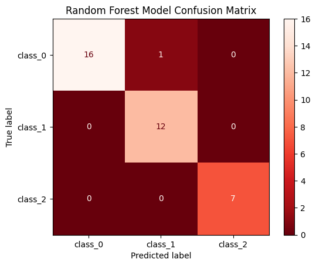

```python
rf_cm = confusion_matrix(y_test, rf_predictions)
            rf_disp = ConfusionMatrixDisplay(confusion_matrix=rf_cm, display_labels= wines.target_names)
            rf_disp.plot(cmap = 'Reds_r')
            plt.title('Random Forest Model Confusion Matrix')
            plt.show()
```

#### **4. Support Vector Machine (SVM) Model**

**Training SVM Model**

```python
# Import libraries
            from sklearn.svm import SVC
            # Define the Model
            svm_model = SVC(random_state=10072025)
            # Train the Model
            svm_model.fit(x_train, y_train)
            # Make Predictions
            svm_predictions = svm_model.predict(x_test)
```

**Evaluating SVM Model**

```python
# Evaluate thr model
            print(f"SVM Model Metrics\n{'*'*40}\nAccuracy Score: {round(accuracy_score(y_test, svm_predictions),4)}")
            print(f"Precision Score: {round(precision_score(y_test, svm_predictions, average='weighted'),4)}")
            print(f"Recall Score: {round(recall_score(y_test, svm_predictions, average='weighted'),4)}")
            print(f"F1 Score: {round(f1_score(y_test, svm_predictions, average='weighted'),4)}")
```

```
SVM Model Metrics
            Accuracy Score: 0.9444
            Precision Score: 0.9524
            Recall Score: 0.9444
            F1 Score: 0.9451
```

**Confusion Matrix**

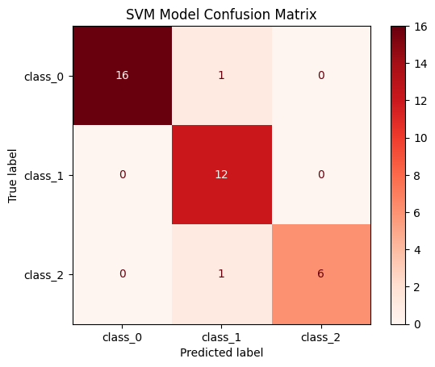

```python
svm_cm = confusion_matrix(y_test, svm_predictions)
            svm_disp = ConfusionMatrixDisplay(confusion_matrix=svm_cm, display_labels= wines.target_names)
            svm_disp.plot(cmap = 'Reds')
            plt.title('SVM Model Confusion Matrix')
            plt.show()
```

#### **5. k-Nearest Neighbours (KNN) Model**

**Training KNN Model**

```python
# Import libraries
            from sklearn.neighbors import KNeighborsClassifier
            # Define the Model
            knn_model = KNeighborsClassifier()
            # Train the Model
            knn_model.fit(x_train, y_train)
            # Make Predictions
            knn_predictions = knn_model.predict(x_test)
```

**Evaluating the KNN Model**

```python
# Evaluate thr model
            print(f"KNN Model Metrics\n{'*'*40}\nAccuracy Score: {round(accuracy_score(y_test, knn_predictions),4)}")
            print(f"Precision Score: {round(precision_score(y_test, knn_predictions, average = 'weighted'),4)}")
            print(f"Recall Score: {round(recall_score(y_test, knn_predictions, average = 'weighted'),4)}")
            print(f"F1 Score: {round(f1_score(y_test, knn_predictions, average = 'weighted'),4)}")
```

```
KNN Model Metrics
            Accuracy Score: 0.9722
            Precision Score: 0.9744
            Recall Score: 0.9722
            F1 Score: 0.9717
```

**Confusion Matrix**

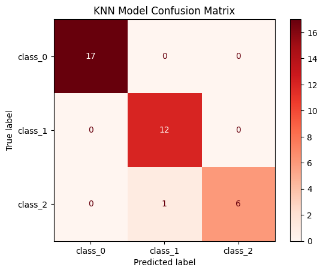

```python
knn_cm = confusion_matrix(y_test, knn_predictions)
            knn_disp = ConfusionMatrixDisplay(confusion_matrix=knn_cm, display_labels= wines.target_names)
            knn_disp.plot(cmap = 'Reds')
            plt.title('KNN Model Confusion Matrix')
            plt.show()
```

#### **6. Naive Bayes Model**

**Training Naive Bayes Model**

```python
# Import libraries
            from sklearn.naive_bayes import GaussianNB
            # Define the Model
            nb_model = GaussianNB()
            # Train the Model
            nb_model.fit(x_train, y_train)
            # Make Predictions
            nb_predictions = nb_model.predict(x_test)
```

**Evaluating Naive Bayes Model**

```python
# Evaluate thr model
            print(f"Naive Bayes Model Metrics\n{'*'*40}\nAccuracy Score: {round(accuracy_score(y_test, nb_predictions),4)}")
            print(f"Precision Score: {round(precision_score(y_test, nb_predictions, average='weighted'),4)}")
            print(f"Recall Score: {round(recall_score(y_test, nb_predictions, average='weighted'),4)}")
            print(f"F1 Score: {round(f1_score(y_test, nb_predictions, average='weighted'),4)}")
```

```
Naive Bayes Model Metrics
            Accuracy Score: 0.9722
            Precision Score: 0.9744
            Recall Score: 0.9722
            F1 Score: 0.9724
```

**Confusion Matrix**

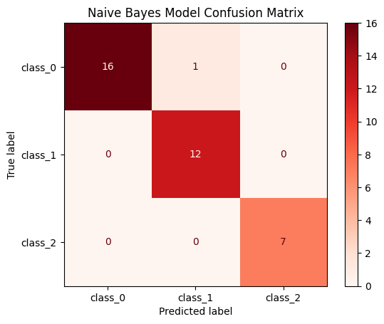

```python
nb_cm = confusion_matrix(y_test, nb_predictions)
            nb_disp = ConfusionMatrixDisplay(confusion_matrix=nb_cm, display_labels= wines.target_names)
            nb_disp.plot(cmap = 'Reds')
            plt.title('Naive Bayes Model Confusion Matrix')
            plt.show()
```

### **Comparing the Models**

```python
# Define a function to compare models

            def compare_models(x_data, y_valid):
            data = {'Model': [], 'Accuracy Score': [], 'Precision Score': [], 'Recall Score': [], 'F1 Score': []}
            models = [lr_model, dt_model, rf_model, svm_model, knn_model, nb_model]
            for model in models:
            predictions = model.predict(x_test)
            data['Model'].append(model.__class__.__name__)
            data['Accuracy Score'].append(round(accuracy_score(y_valid, predictions), 4))
            data['Precision Score'].append(round(precision_score(y_valid, predictions, average='weighted'), 4))
            data['Recall Score'].append(round(recall_score(y_valid, predictions, average='weighted'), 4))
            data['F1 Score'].append(round(f1_score(y_valid, predictions, average='weighted'), 4))
            return pd.DataFrame(data).sort_values(by = ['Accuracy Score', 'F1 Score'], ascending = [False, False])
            compare_models(x_test, y_test)
```

|  | Model | Accuracy Score | Precision Score | Recall Score | F1 Score |
| --- | --- | --- | --- | --- | --- |
| 2 | RandomForestClassifier | 0.9722 | 0.9744 | 0.9722 | 0.9724 |
| 5 | GaussianNB | 0.9722 | 0.9744 | 0.9722 | 0.9724 |
| 0 | LogisticRegression | 0.9722 | 0.9744 | 0.9722 | 0.9717 |
| 4 | KNeighborsClassifier | 0.9722 | 0.9744 | 0.9722 | 0.9717 |
| 3 | SVC | 0.9444 | 0.9524 | 0.9444 | 0.9451 |
| 1 | DecisionTreeClassifier | 0.8611 | 0.8675 | 0.8611 | 0.8628 |

### **Making New Predictions**

```python
def make_new_predictions(data, model = rf_model):
            df = data.copy()
            data[numeric_columns] = scaler.transform(data[numeric_columns])
            predictions = model.predict(data)
            return pd.concat([df, pd.DataFrame(predictions, columns=['predicted_class'])], axis=1)
```

```python
make_new_predictions(pd.DataFrame(wines.data, columns=wines.feature_names)).head()
```

|  | alcohol | malic_acid | ash | alcalinity_of_ash | magnesium | total_phenols | flavanoids | nonflavanoid_phenols | proanthocyanins | color_intensity | hue | od280/od315_of_diluted_wines | proline | predicted_class |
| --- | --- | --- | --- | --- | --- | --- | --- | --- | --- | --- | --- | --- | --- | --- |
| 0 | 14.23 | 1.71 | 2.43 | 15.6 | 127.0 | 2.80 | 3.06 | 0.28 | 2.29 | 5.64 | 1.04 | 3.92 | 1065.0 | 0 |
| 1 | 13.20 | 1.78 | 2.14 | 11.2 | 100.0 | 2.65 | 2.76 | 0.26 | 1.28 | 4.38 | 1.05 | 3.40 | 1050.0 | 0 |
| 2 | 13.16 | 2.36 | 2.67 | 18.6 | 101.0 | 2.80 | 3.24 | 0.30 | 2.81 | 5.68 | 1.03 | 3.17 | 1185.0 | 0 |
| 3 | 14.37 | 1.95 | 2.50 | 16.8 | 113.0 | 3.85 | 3.49 | 0.24 | 2.18 | 7.80 | 0.86 | 3.45 | 1480.0 | 0 |
| 4 | 13.24 | 2.59 | 2.87 | 21.0 | 118.0 | 2.80 | 2.69 | 0.39 | 1.82 | 4.32 | 1.04 | 2.93 | 735.0 | 0 |

```python
print(f'''The Accuracy score of the prediction is {round(accuracy_score(wines.target, make_new_predictions(pd.DataFrame(wines.data, columns=wines.feature_names))["predicted_class"])*100,2)} %''')
```

```
The Accuracy score of the prediction is 99.44 %
```